# final project

### Students Adaptability Level in Online Education

#### context

Since as a beginner in machine learning it would be a great opportunity to try some techniques to predict the outcome of Students’ Adaptability Level Prediction in Online Education using Machine Learning Approaches

#### The feature sets are:

- Gender
- Age
- Education Level
- Institution Type
- IT Student
- Location in Town
- Load-shedding
- Financial Condition
- Internet Type
- Network Type
- Class Duration
- Self LMS
- Device

### Inspiration

-To get an idea about the effectiveness of online education

### Work plan

- 1- Data Exploration & Analysis
- 2- Building a Machine Learning Model /Classification Predict

```python
#Importing the basic librarires for analysis

import numpy as np
import pandas as pd
import seaborn as sns
import matplotlib.pyplot as plt
%matplotlib inline
import plotly.graph_objects as go
import plotly.express as px
```

```python
#Importing the dataset
df =pd.read_csv("C:\\Users\\Rutvik\\Downloads\\students_adaptability_level_online_education.csv")
df
```

|  | Gender | Age | Education Level | Institution Type | IT Student | Location | Load-shedding | Financial Condition | Internet Type | Network Type | Class Duration | Self Lms | Device | Adaptivity Level |
| --- | --- | --- | --- | --- | --- | --- | --- | --- | --- | --- | --- | --- | --- | --- |
| 0 | Boy | 21-25 | University | Non Government | No | Yes | Low | Mid | Wifi | 4G | 3-6 | No | Tab | Moderate |
| 1 | Girl | 21-25 | University | Non Government | No | Yes | High | Mid | Mobile Data | 4G | 1-3 | Yes | Mobile | Moderate |
| 2 | Girl | 16-20 | College | Government | No | Yes | Low | Mid | Wifi | 4G | 1-3 | No | Mobile | Moderate |
| 3 | Girl | 11-15 | School | Non Government | No | Yes | Low | Mid | Mobile Data | 4G | 1-3 | No | Mobile | Moderate |
| 4 | Girl | 16-20 | School | Non Government | No | Yes | Low | Poor | Mobile Data | 3G | 0 | No | Mobile | Low |
| ... | ... | ... | ... | ... | ... | ... | ... | ... | ... | ... | ... | ... | ... | ... |
| 1200 | Girl | 16-20 | College | Non Government | No | Yes | Low | Mid | Wifi | 4G | 1-3 | No | Mobile | Low |
| 1201 | Girl | 16-20 | College | Non Government | No | No | High | Mid | Wifi | 4G | 3-6 | No | Mobile | Moderate |
| 1202 | Boy | 11-15 | School | Non Government | No | Yes | Low | Mid | Mobile Data | 3G | 1-3 | No | Mobile | Moderate |
| 1203 | Girl | 16-20 | College | Non Government | No | No | Low | Mid | Wifi | 4G | 1-3 | No | Mobile | Low |
| 1204 | Girl | 11-15 | School | Non Government | No | Yes | Low | Poor | Mobile Data | 3G | 1-3 | No | Mobile | Moderate |

1205 rows × 14 columns

```python
# look the data set
df.head()
```

|  | Gender | Age | Education Level | Institution Type | IT Student | Location | Load-shedding | Financial Condition | Internet Type | Network Type | Class Duration | Self Lms | Device | Adaptivity Level |
| --- | --- | --- | --- | --- | --- | --- | --- | --- | --- | --- | --- | --- | --- | --- |
| 0 | Boy | 21-25 | University | Non Government | No | Yes | Low | Mid | Wifi | 4G | 3-6 | No | Tab | Moderate |
| 1 | Girl | 21-25 | University | Non Government | No | Yes | High | Mid | Mobile Data | 4G | 1-3 | Yes | Mobile | Moderate |
| 2 | Girl | 16-20 | College | Government | No | Yes | Low | Mid | Wifi | 4G | 1-3 | No | Mobile | Moderate |
| 3 | Girl | 11-15 | School | Non Government | No | Yes | Low | Mid | Mobile Data | 4G | 1-3 | No | Mobile | Moderate |
| 4 | Girl | 16-20 | School | Non Government | No | Yes | Low | Poor | Mobile Data | 3G | 0 | No | Mobile | Low |

```python
df.shape
```

```
(1205, 14)
```

```python
df.size
```

```
16870
```

```python
df.columns
```

```
Index(['Gender', 'Age', 'Education Level', 'Institution Type', 'IT Student',
       'Location', 'Load-shedding', 'Financial Condition', 'Internet Type',
       'Network Type', 'Class Duration', 'Self Lms', 'Device',
       'Adaptivity Level'],
      dtype='object')
```

```python
type(df)
```

[output not shown]

```python
#Checking the dtypes of all the columns
df.info()
```

```
<class 'pandas.core.frame.DataFrame'>
RangeIndex: 1205 entries, 0 to 1204
Data columns (total 14 columns):
 #   Column               Non-Null Count  Dtype
---  ------               --------------  -----
 0   Gender               1205 non-null   object
 1   Age                  1205 non-null   object
 2   Education Level      1205 non-null   object
 3   Institution Type     1205 non-null   object
 4   IT Student           1205 non-null   object
 5   Location             1205 non-null   object
 6   Load-shedding        1205 non-null   object
 7   Financial Condition  1205 non-null   object
 8   Internet Type        1205 non-null   object
 9   Network Type         1205 non-null   object
 10  Class Duration       1205 non-null   object
 11  Self Lms             1205 non-null   object
 12  Device               1205 non-null   object
 13  Adaptivity Level     1205 non-null   object
dtypes: object(14)
memory usage: 131.9+ KB
```

```python
df.describe()
```

[output not shown]

```python
# missing value
df.isnull().sum()
```

```
Gender                 0
Age                    0
Education Level        0
Institution Type       0
IT Student             0
Location               0
Load-shedding          0
Financial Condition    0
Internet Type          0
Network Type           0
Class Duration         0
Self Lms               0
Device                 0
Adaptivity Level       0
dtype: int64
```

#### No any missing values

```python
# look  describe data set
df.describe().T
```

|  | count | unique | top | freq |
| --- | --- | --- | --- | --- |
| Gender | 1205 | 2 | Boy | 663 |
| Age | 1205 | 6 | 21-25 | 374 |
| Education Level | 1205 | 3 | School | 530 |
| Institution Type | 1205 | 2 | Non Government | 823 |
| IT Student | 1205 | 2 | No | 901 |
| Location | 1205 | 2 | Yes | 935 |
| Load-shedding | 1205 | 2 | Low | 1004 |
| Financial Condition | 1205 | 3 | Mid | 878 |
| Internet Type | 1205 | 2 | Mobile Data | 695 |
| Network Type | 1205 | 3 | 4G | 775 |
| Class Duration | 1205 | 3 | 1-3 | 840 |
| Self Lms | 1205 | 2 | No | 995 |
| Device | 1205 | 3 | Mobile | 1013 |
| Adaptivity Level | 1205 | 3 | Moderate | 625 |

### Some Visualizations

```python
target = "Adaptivity Level"
```

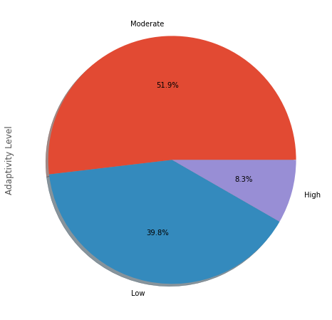

```python
# Show the percentage Adaptivity Level in Dataset
plt.figure(figsize=(12,8))
df['Adaptivity Level'].value_counts().plot.pie(autopct='%1.1f%%',shadow=True)
```

#### The Percentage Adaptivity Level in Datasets:

- Low = 39.8%
- Moderate = 51.9%
- High = 8.3 %

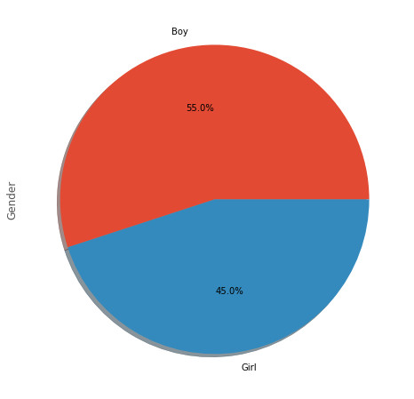

```python
# Show the percentage Gender in Dataset

plt.figure(figsize=(12,8))
df['Gender'].value_counts().plot.pie(autopct='%1.1f%%',shadow=True)
```

#### the percentage Gender in Dataset

- Boy= 55%
- Girl = 45 %

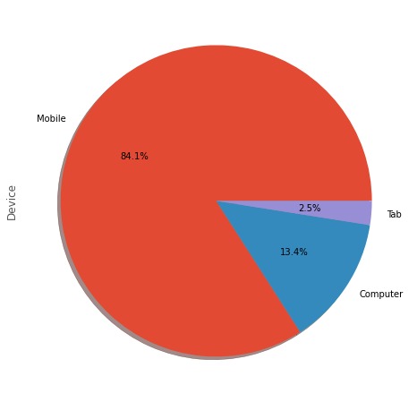

```python
# Show the Device using in Dataset

plt.figure(figsize=(12,8))
df['Device'].value_counts().plot.pie(autopct='%1.1f%%',shadow=True)
```

### The Device using in Dataset

- Mobile = 84.1%
- Computer = 13.4%
- Tab = 2.5%

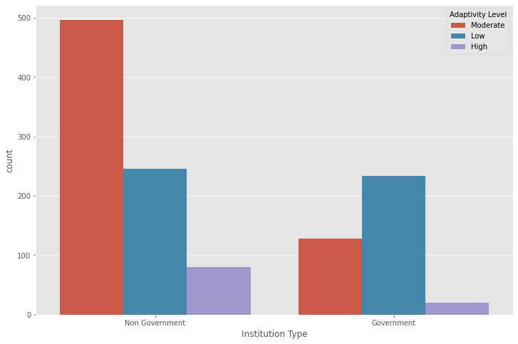

```python
# Show the effect Institution Type in Adaptivity Level using in Dataset

plt.figure(figsize=(12,8))

sns.countplot(df["Institution Type"],hue=df["Adaptivity Level"])
```

- In general, affect Non Government institution highest in Government institution

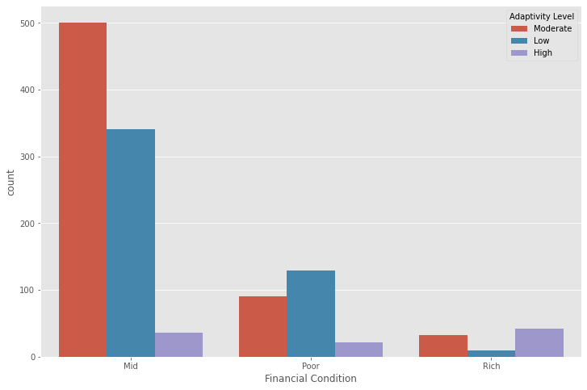

```python
# Show the effect Financial Condition in Adaptivity Level using in Dataset

plt.figure(figsize=(12,8))

sns.countplot(df["Financial Condition"],hue=df["Adaptivity Level"])
```

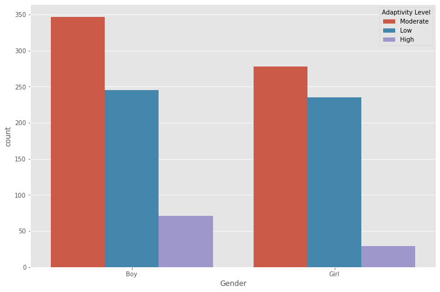

```python
# Show the effect Gender in Adaptivity Level using in Dataset

plt.figure(figsize=(12,8))

sns.countplot(df["Gender"],hue=df["Adaptivity Level"])
```

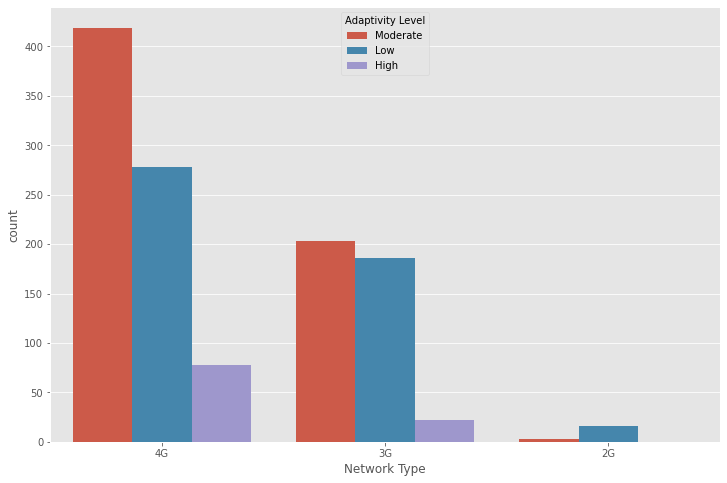

```python
# Show the effect Network Type in Adaptivity Level using in Dataset

plt.figure(figsize=(12,8))
sns.countplot(df["Network Type"],hue=df["Adaptivity Level"])
```

- In general,most the student using 4G , and the Network 4G have the highest progress

# Analysis Results

- After made some visualizations I have some results:

### About Dataset

- Since as a beginner in machine learning it would be a great opportunity to try some techniques to predict the outcome of Students’ Adaptability Level Prediction in Online Education using Machine Learning Approaches
- The shape DataSet -> Rows=1205 / Colums = 14
- The Data type of all the columns = object
- No any missing value

## After Visualizations

#### The percentage Adaptivity Level in Dataset

- Low = 39.8%
- Moderate = 51.9%
- High = 8.3 %

#### The percentage Gender in Dataset

- Boy= 55%
- Girl = 45 %

#### The Device using in Dataset

- Mobile = 84.1%
- Computer = 13.4%
- Tab = 2.5%

#### In general,most the student using 4G , and the Network 4G have the highest progress

## Building a Machine Learning Model /Classification Predict

```python
#Importing the basic librarires for building model - classification

from sklearn.model_selection import train_test_split

from sklearn.metrics import accuracy_score,r2_score

from sklearn.linear_model import LogisticRegression
from sklearn.tree import DecisionTreeClassifier
from sklearn.neighbors import  KNeighborsClassifier
from sklearn.ensemble import RandomForestClassifier
from sklearn.neural_network import  MLPClassifier
from sklearn.svm import SVC
from xgboost import XGBClassifier
import xgboost as xbg

from sklearn.preprocessing import LabelEncoder,StandardScaler
```

```python
df.head()
```

|  | Gender | Age | Education Level | Institution Type | IT Student | Location | Load-shedding | Financial Condition | Internet Type | Network Type | Class Duration | Self Lms | Device | Adaptivity Level |
| --- | --- | --- | --- | --- | --- | --- | --- | --- | --- | --- | --- | --- | --- | --- |
| 0 | Boy | 21-25 | University | Non Government | No | Yes | Low | Mid | Wifi | 4G | 3-6 | No | Tab | Moderate |
| 1 | Girl | 21-25 | University | Non Government | No | Yes | High | Mid | Mobile Data | 4G | 1-3 | Yes | Mobile | Moderate |
| 2 | Girl | 16-20 | College | Government | No | Yes | Low | Mid | Wifi | 4G | 1-3 | No | Mobile | Moderate |
| 3 | Girl | 11-15 | School | Non Government | No | Yes | Low | Mid | Mobile Data | 4G | 1-3 | No | Mobile | Moderate |
| 4 | Girl | 16-20 | School | Non Government | No | Yes | Low | Poor | Mobile Data | 3G | 0 | No | Mobile | Low |

```python
df.info()
```

```
<class 'pandas.core.frame.DataFrame'>
RangeIndex: 1205 entries, 0 to 1204
Data columns (total 14 columns):
 #   Column               Non-Null Count  Dtype
---  ------               --------------  -----
 0   Gender               1205 non-null   object
 1   Age                  1205 non-null   object
 2   Education Level      1205 non-null   object
 3   Institution Type     1205 non-null   object
 4   IT Student           1205 non-null   object
 5   Location             1205 non-null   object
 6   Load-shedding        1205 non-null   object
 7   Financial Condition  1205 non-null   object
 8   Internet Type        1205 non-null   object
 9   Network Type         1205 non-null   object
 10  Class Duration       1205 non-null   object
 11  Self Lms             1205 non-null   object
 12  Device               1205 non-null   object
 13  Adaptivity Level     1205 non-null   object
dtypes: object(14)
memory usage: 131.9+ KB
```

#### We need change all data type using LabelEncode

```python
# change all data type using LabelEncode

data=df

label_encoders = {}
categorical_columns = data.columns
for column in categorical_columns:
    label_encoders[column] = LabelEncoder()
    data[column] = label_encoders[column].fit_transform(data[column])
```

```python
data.head()
```

|  | Gender | Age | Education Level | Institution Type | IT Student | Location | Load-shedding | Financial Condition | Internet Type | Network Type | Class Duration | Self Lms | Device | Adaptivity Level |
| --- | --- | --- | --- | --- | --- | --- | --- | --- | --- | --- | --- | --- | --- | --- |
| 0 | 0 | 3 | 2 | 1 | 0 | 1 | 1 | 0 | 1 | 2 | 2 | 0 | 2 | 2 |
| 1 | 1 | 3 | 2 | 1 | 0 | 1 | 0 | 0 | 0 | 2 | 1 | 1 | 1 | 2 |
| 2 | 1 | 2 | 0 | 0 | 0 | 1 | 1 | 0 | 1 | 2 | 1 | 0 | 1 | 2 |
| 3 | 1 | 1 | 1 | 1 | 0 | 1 | 1 | 0 | 0 | 2 | 1 | 0 | 1 | 2 |
| 4 | 1 | 2 | 1 | 1 | 0 | 1 | 1 | 1 | 0 | 1 | 0 | 0 | 1 | 1 |

```python
#Defined X value and y value , and split the data train
X = data.drop(columns="Adaptivity Level")
y = data["Adaptivity Level"]    # y = quality

# split the data train and test
X_train, X_test, y_train, y_test = train_test_split(X, y, test_size=0.25, random_state=42)

print("X Train : ", X_train.shape)
print("X Test  : ", X_test.shape)
print("Y Train : ", y_train.shape)
print("Y Test  : ", y_test.shape)
```

```
X Train :  (903, 13)
X Test  :  (302, 13)
Y Train :  (903,)
Y Test  :  (302,)
```

```python
#Defined object from library classification

LR = LogisticRegression()
DTR = DecisionTreeClassifier()
RFR = RandomForestClassifier()
KNR = KNeighborsClassifier()
MLP = MLPClassifier()
XGB = XGBClassifier()
SVC=SVC()
```

```python
# make for loop for classification

li = [LR,DTR,RFR,KNR,MLP,KNR,XGB,SVC]
d = {}
for i in li:
    i.fit(X_train,y_train)
    ypred = i.predict(X_test)
    print(i,":",accuracy_score(y_test,ypred)*100)
    d.update({str(i):i.score(X_test,y_test)*100})
```

```
LogisticRegression() : 70.86092715231787
DecisionTreeClassifier() : 90.06622516556291
RandomForestClassifier() : 91.3907284768212
KNeighborsClassifier() : 77.48344370860927
```

```
MLPClassifier() : 79.80132450331125
KNeighborsClassifier() : 77.48344370860927
XGBClassifier(base_score=0.5, booster='gbtree', callbacks=None,
              colsample_bylevel=1, colsample_bynode=1, colsample_bytree=1,
              early_stopping_rounds=None, enable_categorical=False,
              eval_metric=None, feature_types=None, gamma=0, gpu_id=-1,
              grow_policy='depthwise', importance_type=None,
              interaction_constraints='', learning_rate=0.300000012,
              max_bin=256, max_cat_threshold=64, max_cat_to_onehot=4,
              max_delta_step=0, max_depth=6, max_leaves=0, min_child_weight=1,
              missing=nan, monotone_constraints='()', n_estimators=100,
              n_jobs=0, num_parallel_tree=1, objective='multi:softprob',
              predictor='auto', ...) : 91.3907284768212
SVC() : 76.82119205298014
```

- The best XGBClassifier -> 91.4%

```python
print(classification_report(ypred,y_test))
```

```
              precision    recall  f1-score   support

           0       0.52      0.80      0.63        20
           1       0.65      0.88      0.75        94
           2       0.92      0.71      0.80       188

    accuracy                           0.77       302
   macro avg       0.70      0.80      0.73       302
weighted avg       0.81      0.77      0.77       302
```

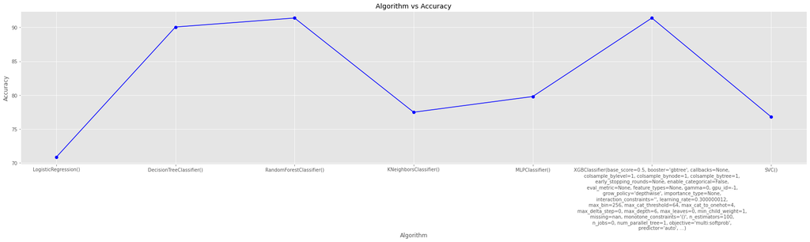

```python
# make graph about Accuracy

plt.figure(figsize=(30, 6))
plt.title("Algorithm vs Accuracy")
plt.xlabel("Algorithm")
plt.ylabel("Accuracy")
plt.plot(d.keys(),d.values(),marker='o',color='blue')
plt.show()
```

```python
dtree1 = DecisionTreeClassifier(random_state=42)
dtree1 = dtree1.fit(X_train, y_train)
dtpred1 = dtree1.predict(X_test)
```

[figure not shown]

```python
from sklearn.tree import plot_tree
dec_tree = plot_tree(decision_tree=dtree1, feature_names = X_train.columns,
                     class_names =["0", "1", "2"] , filled = True , precision = 4, rounded = True)
```